# Keywords In Context

# 1 KWIC

In this Notebook we will introduce you to an example of KeyWords In Context. In a later PDF handout you will be introduced to the Orange3 Tool which allows you to perform KWIC and more complex tasks via a drag and drop GUI.

## 1.1 Load

```r
file.jobs <- "../../DATA/MonsterBoard-2013-n=20000.Rdata"
load(file.jobs)
```

## 1.2 Job Description

Let’s get a feeling for the Job descriptions.

```r
sp(library(ggplot2))
library(ggthemes)
# Names of the dimensions
names(sample)
```

```
 [1] "PositionAdID"     "PositionID"       "JobTitle"         "City"             "PostalCode"       "SalaryTypeID"     "SalaryFrom"
 [8] "SalaryTo"         "CareerLevelID"    "EducationLevelID" "DateActive"       "DateExpires"      "JobAttributeIDs"  "JobCategoryIDs"
[15] "OccupationIDs"    "IndustryIDs"      "Keywords"         "JobBody"
```

```r
# What is the type of the JobBody dimension
class(sample$JobBody)
```

```
[1] "character"
```

```r
# Lets look at how many characters a Jobbody has and place them in a data.frame with one column
jb.len <- as.data.frame(nchar(sample$JobBody))
names(jb.len) <- "No.Characters"
# What does the data look like
head(jb.len)
```

|  | No.Characters |
| --- | --- |
| 1 | 2023 |
| 2 | 686 |
| 3 | 875 |
| 4 | 819 |
| 5 | 1026 |
| 6 | 930 |

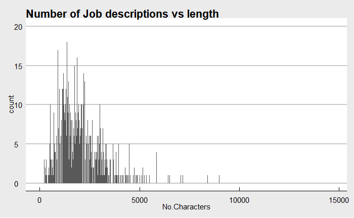

```r
# Make a nice bar chart
ggplot(jb.len, aes(x=No.Characters))+ geom_bar()+
    ggtitle("Number of Job descriptions vs length") +
    ylim(0,20)+theme_economist_white()
```

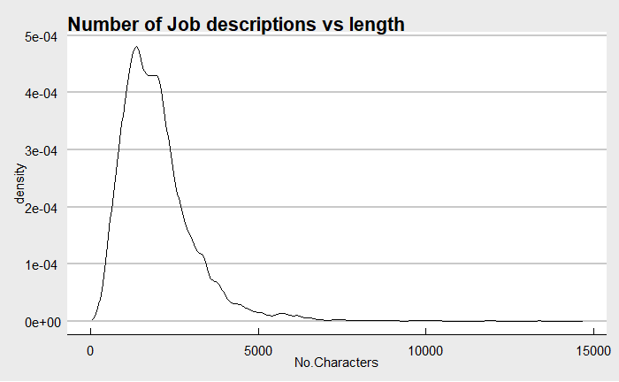

```r
# A density plot is easier to the eyes
ggplot(jb.len, aes(x=No.Characters))+ geom_density()+
    ggtitle("Number of Job descriptions vs length") +
    theme_economist_white()
```

```r
# What is the mean length
# If you want a more robust mean look at trimming out the extreme values
# ?mean
mean(jb.len$No.Characters)
```

```
[1] 1982.087
```

## 1.3 Naming conventions

Notice we loaded in the sample set of job adverts with the name `sample`. This has the same name as a function that samples data. Luckily, R understands the difference between a `function` and a `data.table` by the context in which it is called.

To avoid issues you will need to be consistent with your naming conventions. And yes it is easy not to be consistent.

A great Blog on this subject you can find [here](https://www.r-bloggers.com/2014/07/consistent-naming-conventions-in-r/).

The blogger suggests one of the following 5 approaches

1. alllowercase: e.g. `adjustcolor`
2. period.separated: e.g. `plot.new`
3. underscore_separated: e.g. `numeric_version`
4. lowerCamelCase: e.g. `addTaskCallback`
5. UpperCamelCase: e.g. `SignatureMethod`

And of course make sure your names have a meaning.

For those of you looking for a Job at Google. Here is their [naming conventions](https://google.github.io/styleguide/Rguide.html).